# Project Report

The S&P

Author

Kota Suzuki, Radhika Todi, Naoki Ito, and Julianne Sun

Published

March 7, 2023

Abstract

*With the emergence of climate change as a real, immediate threat to the world, businesses are no longer expected to consider environmental risks as mere business disruptors or social responsibility goals, but rather a threat and an obligation robustly intertwined with their financial risk management. Therefore we ask ourselves the question, “can we classify the goodness of ethical management practices of companies solely based on financial indicators?” This question will be answered by looking into crucial variables such as market capitalization, current ratio, debt asset, industry sector, and many others — all financial indicators readily available to investors and economists who can easily use our findings to translate such financial data into a measure of environmental consciousness. To classify the elusive notion of “goodness,” we define ESG scores below the median as bad and above the median as good, allowing for a classification, prediction problem to be formed around this normalized variable. Because our problem revolves around our ability to classify good versus bad scores — which is assigned a value of zero and one, respectively — we will prioritize the optimization of accuracy in our model that helps translate financial variables into a measure of environmental, ethical wellbeing*.

## 2 Problem statement

Describe your problem statement. Articulate your objectives using absolutely no jargon. Interpret the problem as inference and/or prediction.

**Can we classify the goodness of ethical management practices of companies solely based on financial indicators?**

This question, which strives to translate purely financial metrics into a measure of ethical, environmental righteousness, is therefore a classification problem focused on prediction.

## 3 Data sources

What data did you use? Provide details about your data. Include links to data if you are using open-access data.

We obtained two datasets from the Wharton Research Data Service (WRDS): S&P Global ESG Score dataset, and the Fundamental Annuals and Security Daily dataset, both of which are not open-access. We were given access to these two datasets from a Kellog professor. The first dataset provides the ESG scores, ranging from 0 to 100, for numerous companies on an international scale. For the purposes of this project, we focused on the environmental dimension, which is the weighted-average score of the sub-dimensional scores of each company’s environment and climate-related activities. The second dataset hosts several key financial metrics that measures the company’s financial health, such as profitability, liquidity, efficiency, and solvency. We used this dataset to collect or calculate numerous financial indicators such as gross profit margin, return on equity, book to market, current ratio, debt-assets ratio, asset turnover, as well as market capitalization.

## 4 Stakeholders

Who cares? If you are successful, what difference will it make to them?

We consider four main stakeholders in our project: 1. Investors 2. Policymakers 3. Journalists 4. Economists

Investors are increasingly interested in the environmental risk management of companies since climate change disasters — such as the wildfires that took down PG&E — are becoming more and more of a tangible, immediate threat. According to the Harvard Business Review, the top-rated funds in terms of sustainability have attracted much more capital than lower-rated funds, which seems to indicate that investors are paying significant attention to ESG scores. Our results would also be of interest to policy makers, as it could provide them insight into the best ways to foster company growth while punishing negative externalities such as air and water pollution. Knowing how financial indicators affect the ESG score will help policymakers conceptualize the relationship between financial wellbeing and environmental righteousness, which will hopefully lead to effective policies that would benefit both the environment and the economy without hurting either. Both journalists and economists can use our results to better report on and understand the relationship between companies’ financial health and ethical environmental behavior. Since this concept of environmental risk management is such a novel one, it is important that the journalists and economists — those who are responsible for connecting the general public to the conduct of giant corporations — are well informed about the relationship between financial metrics and environmental goodness.

## 5 Data quality check / cleaning / preparation

In a tabular form, show the distribution of values of each variable used in the analysis - for both categorical and continuous variables. Distribution of a categorical variable must include the number of missing values, the number of unique values, the frequency of all its levels. If a categorical variable has too many levels, you may just include the counts of the top 3-5 levels.

If the tables in this section take too much space, you may put them in the appendix, and just mention any useful insights you obtained from the data quality check that helped you develop the model or helped you realize the necessary data cleaning / preparation.

Were there any potentially incorrect values of variables that required cleaning? If yes, how did you clean them?

Did you do any data wrangling or data preparation before the data was ready to use for model development? Did you create any new predictors from exisiting predictors? For example, if you have number of transactions and spend in a credit card dataset, you may create spend per transaction for predicting if a customer pays their credit card bill. Mention the steps at a broad level, you may put minor details in the appendix. Only mention the steps that ended up being useful towards developing your final model(s).

```python
# importing necessary packages
import pandas as pd
import numpy as np
import seaborn as sns
import statsmodels.formula.api as sm
import matplotlib.pyplot as plt

pd.set_option('display.max_columns', None)
import warnings
warnings.filterwarnings("ignore")

# reading in all of our data
esg = pd.read_csv('ESG_scoredata/ESG_scoredata.csv')
ratios = pd.read_csv('ESG_scoredata/financial_ratios.csv')
securitydaily = pd.read_csv('ESG_scoredata/security_daily.csv')
```

### 5.1 Distribution of continuous variables

```python
# distribution of numerical variables in esg dataset
esg.describe()
```

|  | institutionid | assessmentyear | scorevalue | scoreweight | industryrank | companyid | gvkey |
| --- | --- | --- | --- | --- | --- | --- | --- |
| count | 6.486140e+05 | 648614.000000 | 638002.000000 | 624328.000000 | 638002.000000 | 6.486140e+05 | 648614.000000 |
| mean | 3.976814e+06 | 2018.917060 | 26.108341 | 7.783369 | 69.895756 | 3.479973e+07 | 56410.346328 |
| std | 2.089602e+06 | 2.475546 | 23.463936 | 10.165602 | 84.848632 | 9.872846e+07 | 66059.249599 |
| min | 1.000030e+05 | 2013.000000 | 0.000000 | 1.000000 | 1.000000 | 1.867100e+04 | 1004.000000 |
| 25% | 4.048147e+06 | 2017.000000 | 3.000000 | 3.000000 | 16.000000 | 1.894880e+05 | 9850.000000 |
| 50% | 4.152463e+06 | 2020.000000 | 22.000000 | 4.000000 | 40.000000 | 3.149600e+05 | 24447.000000 |
| 75% | 4.810658e+06 | 2021.000000 | 40.000000 | 7.000000 | 89.000000 | 4.180463e+06 | 105365.000000 |
| max | 2.972477e+07 | 2022.000000 | 100.000000 | 55.000000 | 743.000000 | 1.678014e+09 | 345189.000000 |

```python
# distribution of numerical variables in ratios dataset
ratios.describe()
```

|  | gvkey | bm | gpm | roe | debt_assets | curr_ratio | at_turn |
| --- | --- | --- | --- | --- | --- | --- | --- |
| count | 435916.000000 | 414052.000000 | 410332.000000 | 405950.000000 | 433393.000000 | 356166.000000 | 410741.000000 |
| mean | 66462.537129 | 0.899641 | -6.109597 | -0.739567 | 0.584153 | 4.376325 | 0.778087 |
| std | 68039.128791 | 139.078975 | 177.892534 | 82.514665 | 0.847386 | 90.881193 | 0.809226 |
| min | 1004.000000 | 0.000000 | -28202.000000 | -21888.000000 | 0.000000 | 0.000000 | 0.000000 |
| 25% | 14793.000000 | 0.247000 | 0.215000 | -0.139000 | 0.346000 | 1.332000 | 0.215000 |
| 50% | 29914.000000 | 0.491000 | 0.391000 | 0.060000 | 0.571000 | 2.100000 | 0.602000 |
| 75% | 133868.000000 | 0.830000 | 0.656000 | 0.133000 | 0.799000 | 3.700000 | 1.084000 |
| max | 349972.000000 | 89351.100000 | 2.628000 | 5303.740000 | 340.654000 | 13528.100000 | 35.112000 |

```python
# distribution of numerical variables in security dataset
securitydaily.describe()
```

|  | gvkey | ajexdi | cshoc | prccd | trfd |
| --- | --- | --- | --- | --- | --- |
| count | 4.693155e+07 | 4.691145e+07 | 4.590000e+07 | 4.691017e+07 | 2.729079e+07 |
| mean | 9.494989e+04 | 9.865210e-01 | 2.882302e+09 | 7.643682e+01 | 2.660211e+09 |
| std | 7.632956e+04 | 3.289092e+00 | 1.954235e+12 | 4.135382e+03 | 3.270882e+11 |
| min | 1.003000e+03 | 0.000000e+00 | 0.000000e+00 | 0.000000e+00 | 1.000000e+00 |
| 25% | 2.354600e+04 | 1.000000e+00 | 7.637000e+06 | 3.500000e-01 | 1.048558e+00 |
| 50% | 6.585100e+04 | 1.000000e+00 | 3.402600e+07 | 9.990000e+00 | 1.218091e+00 |
| 75% | 1.707810e+05 | 1.000000e+00 | 1.132790e+08 | 2.590000e+01 | 1.738440e+00 |
| max | 3.539450e+05 | 1.000000e+03 | 1.582449e+15 | 8.711790e+06 | 4.408022e+13 |

### 5.2 Distribution of categorical variables

```python
# number of missing categorical values for esg dataset
esg_categorical = esg.loc[:,esg.dtypes==np.object]
esg_categorical.isnull().sum()
```

```
scoreid                             0
dimensionscoreid                    0
scoredate                           0
csaindustryname                     0
csaindustrygroupname                0
csaindustryclassificationname       0
csasectorname                       0
scoretype                           0
dimensionname                       0
aspectname                          0
ticker                           1205
companyname                         0
country                             0
simpleindustry                      0
dtype: int64
```

```python
# number of unique categorical values for esg dataset
esg_categorical.nunique()
```

```
scoreid                          13161
dimensionscoreid                 23826
scoredate                           65
csaindustryname                     62
csaindustrygroupname                24
csaindustryclassificationname        1
csasectorname                       11
scoretype                            3
dimensionname                        4
aspectname                         111
ticker                            2615
companyname                       2627
country                              1
simpleindustry                      68
dtype: int64
```

```python
# number of missing categorical values for ratios dataset
ratios_categorical = ratios.loc[:,ratios.dtypes==np.object]
ratios_categorical.isnull().sum()
```

```
adate            2727
qdate               0
public_date         0
divyield       269366
TICKER           2757
cusip            2423
dtype: int64
```

```python
# number of unique categorical values for ratios dataset
ratios_categorical.nunique()
```

```
adate           131
qdate           123
public_date     120
divyield       2111
TICKER         6813
cusip          7781
dtype: int64
```

```python
# number of missing categorical values for security dataset
security_categorical = securitydaily.loc[:,securitydaily.dtypes==np.object]
security_categorical.isnull().sum()
```

```
iid            0
datadate       0
tic         4933
cusip          0
conm           0
dtype: int64
```

```python
# number of unique categorical values for ratios dataset
security_categorical.nunique()
```

```
iid           213
datadate     2597
tic         36661
cusip       32874
conm        26983
dtype: int64
```

```python
# The frequency of all observations for csasectorname
esg_categorical['csasectorname'].value_counts()
```

```
Financials                103774
Information Technology     88809
Health Care                87432
Industrials                87203
Consumer Discretionary     83555
Real Estate                43637
Consumer Staples           35751
Materials                  33938
Energy                     30775
Utilities                  27748
Communication Services     25992
Name: csasectorname, dtype: int64
```

We first started the data preparation endeavor by subsetting the Environmental Dimension score data from the ESG dataset. Even though there are some companies with multiple score assessments per year, we assume that the change is rather trivial and hence use the same financial indicators. This is because our primary interest is to analyze and capture the general overview of the relationship between financial measures and the scores, and not to conduct an event study regarding the change in scores triggered by the financial measures.

Since we are modeling a logistic regression, we normalized the score between 0 to 1 without affecting the distribution. Next, we directly utilized the financial ratio dataset that is pre-processed based on the company’s fundamental annuals dataset. Since we are only considering the yearly data, we take the latest available data for each of the company-year levels. Using the security daily dataset, market capitalization is calculated by multiplying the close price of stock and the number of shares outstanding, adjusted by the daily adjustment factor on a daily basis. Again, since we only consider the year-level for each company, we average the market capitalization for every company-year level. Given the three datasets, the final dataset we use in the analysis is created by inner joins based on year and 2 company identifiers: `gvkey` and `ticker`.

## 6 Exploratory data analysis

Put the relevant EDA here (visualizations, tables, etc.) that helped you figure out useful predictors for developing the model(s). Only put the EDA that ended up being useful towards developing your final model(s).

List the insights (as bullet points) you got from EDA that ended up being useful towards developing your final model.

Again, if there are too many plots / tables, you may put them into appendix, and just mention the insights you got from them.

```python
# Finding best aspect of environmental data to use:
environmental = pd.read_csv("environmental_data.csv")
environmental['aspectname'].value_counts().head(5)
```

```
Environmental Dimension                      18383
Environmental Reporting                      18366
Operational Eco-Efficiency                   18336
Climate Strategy                             17205
Environmental Policy & Management Systems    16496
Name: aspectname, dtype: int64
```

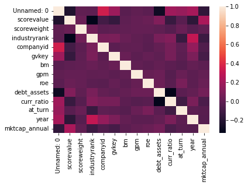

```python
# Identifying variables with high correlation:
sns.heatmap(environmental.corr())
```

```python
# Selecting the Environmental Dimension aspect based on EDA findings
data_subset = environmental[environmental.aspectname=='Environmental Dimension']

# normalizing score value to a 0-1 scale
environmentcopy = data_subset.copy()
environmentcopy['scorevalue'] = (environmentcopy['scorevalue'] - environmentcopy['scorevalue'].min()) / (environmentcopy['scorevalue'].max() - environmentcopy['scorevalue'].min())

# Defining score values above the median score as good(1) and score values below the median score as bad(0)
environmentcopy.loc[:,'scorevalue'] = environmentcopy.loc[:,'scorevalue'].apply(lambda x: 1 if x>environmentcopy.scorevalue.median() else 0)

#Randomly selecting 80% of observations as training data and 20% of the observations as testing data
training_data = environmentcopy.sample(frac=0.8, random_state=20)
testing_data = environmentcopy.drop(training_data.index)
```

```
Optimization terminated successfully.
         Current function value: 0.617318
         Iterations 5
```

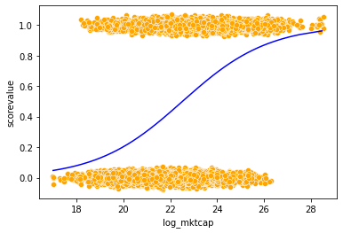

```python
# calculating log of marketcap
environmentcopy['log_mktcap'] = np.log(environmentcopy['mktcap_annual'])
training_data['log_mktcap'] = np.log(training_data['mktcap_annual'])
testing_data['log_mktcap'] = np.log(testing_data['mktcap_annual'])

# defining jitter function
def jitter(values,j):
    return values + np.random.normal(j,0.02,values.shape)
sns.scatterplot(x = jitter(environmentcopy.log_mktcap,0), y = jitter(environmentcopy.scorevalue,0), data = environmentcopy, color = 'orange')

# plotting line for yes transformation
logit_model = sm.logit(formula = 'scorevalue~log_mktcap', data = training_data).fit()
sns.lineplot(x = 'log_mktcap', y= logit_model.predict(testing_data), data = environmentcopy, color = 'blue')
```

```
Optimization terminated successfully.
         Current function value: 0.672610
         Iterations 5
```

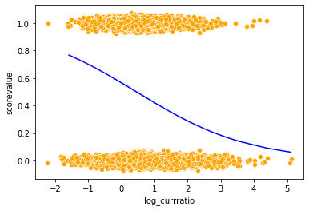

```python
# calculating log of current ratio
environmentcopy['log_currratio'] = np.log(environmentcopy['curr_ratio'])
training_data['log_currratio'] = np.log(training_data['curr_ratio'])
testing_data['log_currratio'] = np.log(testing_data['curr_ratio'])

# Jittering points to better see the density of points in any given region of the plot
sns.scatterplot(x = jitter(environmentcopy.log_currratio,0), y = jitter(environmentcopy.scorevalue,0), data = environmentcopy, color = 'orange')

# plotting line for yes transformation
logit_model = sm.logit(formula = 'scorevalue~log_currratio', data = training_data).fit()
sns.lineplot(x = 'log_currratio', y= logit_model.predict(testing_data), data = environmentcopy, color = 'blue')
```

```
Optimization terminated successfully.
         Current function value: 0.675617
         Iterations 5
-9935.61791768595
```

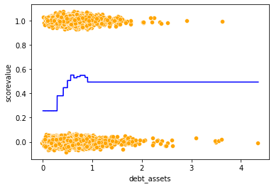

```python
# defining function to bin debt assets so that it can be applied to both the test and train datasets
def var_transform(data):
    binned_debt_assets = pd.qcut(environmentcopy['debt_assets'],10,retbins=True)
    bins = binned_debt_assets[1]
    data['binned_debt_assets'] = pd.cut(data['debt_assets'],bins = bins)
    dum = pd.get_dummies(data.binned_debt_assets,drop_first = True)
    dum.columns = ['debt_assets'+str(x) for x in range(1,len(bins)-1)]
    data = pd.concat([data,dum], axis = 1)
    return data

training_data = var_transform(training_data)
testing_data = var_transform(testing_data)

# Model with binned debt_assets
sns.scatterplot(x = jitter(training_data.debt_assets,0), y = jitter(training_data.scorevalue,0), data = training_data, color = 'orange')
logit_model = sm.logit(formula = 'scorevalue~' + '+'.join(['debt_assets'+str(x) for x in range(1,10)]), data = training_data).fit()
sns.lineplot(x = 'debt_assets', y= logit_model.predict(training_data), data = training_data, color = 'blue')
```

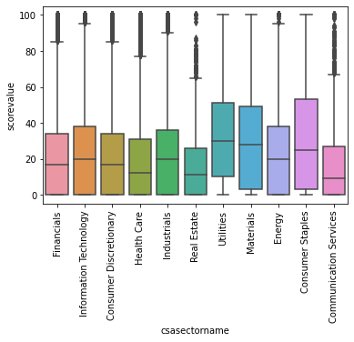

```python
# building boxplot for sectors to see distribution
sns.boxplot(data=environmental, x="csasectorname", y="scorevalue")
plt.xticks(rotation=90);
```

Final Insights:  
- `Environmental Dimension` had the least number of null values and the most observations out of all aspects within the environment dataset, making it the optimal choice. Furthermore, intuitively, “Environmental Dimension” best captures the holistic evaluation of the environmental factor, making it the best sub-sector of environment to analyze - `mktcap_annual`, `curr_ratio`, `debt_assets` have relatively high correlations — for this reason, we initially looked at these variables to try and optimize them as predictors - Both `mktcap_annual` and `curr_ratio` have extremely high outliers that makes the logistic regression model fit poorly for companies with low values in market cap or current ratio. To fix this we applied a log transformation for both of these variables, allowing the model to better fit both ends of the predictor variable more accurately. - `debt_assets` has a unique, negative-parabolic shape in relation to `scorevalue` which could not be captured without a transformation. To make sure this relationship with our response variable could be accurately portrayed, we fitted a binned version of `debt_assets` which does well to illustrate that negative parabola. - The median score value seems to depend on what industry the company is in, making `csasectorname` a reliable predictor. This conclusion can also be reached intuitively, as different industries will inevitably interact with the environment in different ways.

## 7 Approach

What kind of a model (linear / logistic / other) did you use? What performance metric(s) did you optimize and why?

Is there anything unorthodox / new in your approach?

What problems did you anticipate? What problems did you encounter? Did the very first model you tried work?

Did your problem already have solution(s) (posted on Kaggle or elsewhere). If yes, then how did you build upon those solutions, what did you do differently? Is your model better as compared to those solutions in terms of prediction / inference?

**Important: Mention any code repositories (with citations) or other sources that you used, and specifically what changes you made to them for your project.**

Firstly, this problem of classifying the environmental goodness of companies based solely on financial metrics — to our knowledge — is entirely new. This dataset, since it is not open-access, cannot be found on Kaggle. Since this problem is unique and unexplored, we anticipated a lot of struggle with building the proper dataset to find the answer to this question. The ESG dataset, which originally gave us the inspiration for this question, did not include any financial indicators that we could use to start building a model, meaning we had to calculate or find these metrics on our own using other datasets.

Since we are looking to classify a company’s score as either “good” or “bad” — on a binary scale — we used a logistic model focused on optimizing accuracy. One of our goals was to eliminate as much subjectivity from the scoring process as possible, which is why we chose the binary measurement of good or bad, allowing us to bypass the subtle differences between classifying a score of, for example, 52 versus 53. Accuracy, then, is the best metric to optimize, since it best captures the model’s capabilities of classifying a score as good or bad.

The model-building process was, as expected, very arduous, because this is a question that strives to convert financial metrics into a measure of ethical goodness. Many financial metrics that we calculated ended up not being significant or useful, including gross profit margin, asset turnover, and book to market. We tried fitting these financial predictors into the original model, but they ended up fruitless, meaning we needed to abandon them as predictors. While there were some obstacles along the way, we believe that to some extent, financial indicators can be used to predict ethical management practices.

## 8 Developing the model

Explain the steps taken to develop and improve the base model - informative visualizations / addressing modeling assumption violations / variable transformation / interactions / outlier treatment / influential points treatment / addressing over-fitting / addressing multicollinearity / variable selection - stepwise regression, lasso, ridge regression).

Did you succeed in achieving your goal, or did you fail? Why?

**Put the final model equation**.

**Important: This section should be rigorous and thorough. Present detailed information about decision you made, why you made them, and any evidence/experimentation to back them up.**

**Variable Transformations:** Using the insight we garnered from the EDA section of our project, which allowed us to better understand the distribution and relationship of each predictor variable to the `scorevalue` response variable, we conducted the following variable transformations on the following predictors:

1. `mktcap_annual`: since there are some extremely high outliers for market capitalization, the model does poorly when classifying scores for companies with low market capitalization values. Therefore, applying a log transformation on this variable helps the predictor classify low and high market capitalization values better.
2. `curr_ratio`: similar to `mktcap_annual`, this variable had extremely high outliers that affected its performance as a predictor in a similar manner. Applying a log transformation helped reduce the range of the values within this predictor, allowing it to better classify for observations with low values of `curr_ratio`.
3. `debt_assets`: this variable had a unique, negative-parabolic relationship with `scorevalue`, which was hard to capture without a transformation. To best capture this relationship, we binned `debt_assets` into ten different categories which helped the predictor variable better represent its relationship with the response variable.

**Addressing outliers and influential points in the logistic regression:** Since we established the linearity of the predictors with the logistic regression through transformation and influential points don’t have a strong influence on the overall logistic model, we decided not to remove any points from the dataset. We did calculate the residuals of the model to the test data but didn’t find it to be very useful.

**Variable Selection:** We identified 4 important financial predictors (log annual market cap, log current ratio, roe, debt assets) and used best subset selection to find the best combination of the first-order predictors and their interaction terms. Best model selection was a good option since we had only 4 predictors and Best Model Selection would consider all the possible models and would not be too computationally complex. The model with 7 predictors was the best model according to the BIC criterion.

The 7 predictors suggested by the Best Subset model were: log annual market cap, debt assets, the interaction between log annual market cap and log current ratio, the interaction between log annual market cap and debt assets, the interaction between log current ratio and roe, the interaction between log current ratio and debt assets, and the interaction between roe and debt assets.

While we used the debt assets variable as is for the interaction terms, we included the binned debt assets variable as a first-order predictor. Based on the EDA, we also included the variable `csasectorname` ( a categorical variable of 11 industry sectors).

**Final model equation:**

ScoreValue = -9.6427 + 1.0706*`csasectorname`[T.Consumer Discretionary]+1.2814*`csasectorname`[T.Consumer Staples]+1.2789*`csasectorname`[T.Energy]+1.0857*`csasectorname`[T.Financials]+0.6537*`csasectorname`[T.Health Care]+1.4517*`csasectorname`[T.Industrials]+1.0799*`csasectorname`[T.Information Technology]+1.9563*`csasectorname`[T.Materials]+0.4983*`csasectorname`[T.Real Estate]+1.4832*`csasectorname`[T.Utilities]+0.3572*`log_mktcap` - 8.0657*`debt_assets` - 0.0055*`log_mktcap_log_currratio` + 0.3537*`log_mktcap_debt_assets` + 0.1100*`log_currratio_roe` + 0.0593*`log_currratio_debt_assets` - 0.1133*`roe_debt_assets` + 0.3656*`debt_assets1` + 0.4666*`debt_assets2` + 0.5786*`debt_assets3` + 0.7014*`debt_assets4` + 0.5920*`debt_assets5` + 0.6923*`debt_assets6` + 0.8214*`debt_assets7` + 1.0873*`debt_assets8` + 0.6764*`debt_assets9`

**Success of the final model:**

## 9 Limitations of the model with regard to inference / prediction

If it is inference, will the inference hold for a certain period of time, for a certain subset of population, and / or for certain conditions.

If it is prediction, then will it be possible / convenient / expensive for the stakeholders to collect the data relating to the predictors in the model. Using your model, how soon will the stakeholder be able to predict the outcome before the outcome occurs. For example, if the model predicts the number of bikes people will rent in Evanston on a certain day, then how many days before that day will your model be able to make the prediction. This will depend on how soon the data that your model uses becomes available. If you are predicting election results, how many days / weeks / months / years before the election can you predict the results.

When will your model become too obsolete to be useful?

There are mainly three limitations we faced during our analysis.  
First, the methodology of S&P’s ESG scoring is very complicated, making it difficult to extrapolate what is already taken into account and what is not. This makes it hard for us to infer whether the ethical management is actually correlated with the financial indicators or rather the S&P’s scoring methodology is simply biased to the characteristics we found.  
Second, in order for the model to be used for inference, we have to utilize the panel data methods considering the company-year level. However, we do not have enough observations to pursue this method as we only have about 10 years of data collected annually for each company. Therefore, we decided not to pursue how exactly the predictors are related to the ethical management practices, and only examine whether the predictors have predictive power of the environmental score.  
Lastly, we only considered the observations for the companies in the US because we suspect that the trend could be significantly different between countries. Hence, if we want to create a model that is universally applicable, we may have to include the numerous interactions of predictors with the country categorical variable, which would rapidly inflate the number of predictors. Since we dropped all the observations with missing values in at least one of the variables, our sample is small. Therefore, having too many predictors could suffer from the overfitting, losing the predictive power on the testing data.

## 10 Conclusions and Recommendations to stakeholder(s)

What conclusions do you draw based on your model? If it is inference you may draw conclusions based on the coefficients, statistical significance of predictors / interactions, etc. If it is prediction, you may draw conclusions based on prediction accuracy, or other performance metrics.

How do you use those conclusions to come up with meaningful recommendations for stakeholders? The recommendations must be action-items for stakeholders that they can directly implement without any further analysis. Be as precise as possible. The stakeholder(s) are depending on you to come up with practically implementable recommendations, instead of having to think for themselves.

If your recommendations are not practically implementable by stakeholders, how will they help them? Is there some additional data / analysis / domain expertise you need to do to make the recommendations implementable?

Do the stakeholder(s) need to be aware about some limitations of your model? Is your model only good for one-time use, or is it possible to update your model at a certain frequency (based on recent data) to keep using it in the future? If it can be used in the future, then for how far into the future?

With the building of our final model — achieving a prediction accuracy of around 70% on testing data — we establish that, to some extent, it is possible to predict the ethical goodness of companies solely based on the company’s business characteristics and other financial metrics. As climate change and environmental consciousness becomes increasingly relevant, not just in the eyes of businesses and investors, but to the entirety of the world itself, our question also becomes increasingly important.

The scope of our question can be seen in the variety of our stakeholders as well, expanding past investors and applying to policymakers, journalists, and economists. While this model will be very relevant for investors, as they can easily access financial datasets and then use our conclusions to translate that information into a measure of ethical management practices, our work can be used by policymakers to regulate and better score companies for the wellbeing of the planet and by journalists and economists to hold companies accountable for their environmental actions in accordance with their financial character.

## GitHub and individual contribution

Add details of each team member’s contribution in the table below.

## Individual contribution

| Team member | Contributed aspects | Details | Number of GitHub commits |
| --- | --- | --- | --- |
| Naoki Ito | Data cleaning and Model Formulation | Selection of variables, merging of datasets, direction of analysis. | 2 |
| Kota Suzuki | EDA, Variable Transformations, and Model Formulation | Claculated Financial variables, conducted variable transformations based on EDA findings, inserted said variable transformation into the final model. | 2 |
| Radhika Todi | EDA,model formulation, developing the final model | Variable selection (best subset selection), optimal decision threshold, ROC curve, Precision-Recall curve, Confusion Matrices. | 1 |
| Julianne Sun | Outliers/influential points, model formulation | Identified outliers and influential points and their effect on the model. | 2 |

List the **challenges** you faced when collaborating with the team on GitHub. Are you comfortable using GitHub? Do you feel GitHuB made collaboration easier? If not, then why? *(Individual team members can put their opinion separately, if different from the rest of the team)*

We gathered in-person and collaborated on a regular basis to discuss ideas and implement models together. Therefore, we did not send the scripts and codes back and forth, and so the numbers of commits are low. This is because our analysis required more of a qualitative argument and less technical code implementation.

## References

List and number all bibliographical references. When referenced in the text, enclose the citation number in square brackets, for example [1].

[1] Bhagat, S. (2022, March 31). An inconvenient truth about ESG investing. Harvard Business Review. Retrieved March 11, 2023, from https://hbr.org/2022/03/an-inconvenient-truth-about-esg-investing

[2] Gold, R. (2019, January 21). PG&E: The first climate-change bankruptcy, probably not the last. The Wall Street Journal. Retrieved March 11, 2023, from https://www.wsj.com/articles/pg-e-wildfires-and-the-first-climate-change-bankruptcy-11547820006